# Facial_detection_modal

### PFA: Facial expression recognition

##### **Goals:**

- Successfully detect a face, eyes, mouth and eyebrows
- Successfully predict emotions from pictures by training a model
- Increase efficiency of the program
- Generalize the predictions to live camera and build first version of final model
- Generalize the predictions to any video.
- Wrap the result in an adequate python UI or compile to app

##### **Additional functions we can add:**

- Save person's information and face after analysing emotions

```python
#####################################################################################################
```

```python
#####################################################################################################
```

### 1. Face detection

#### 1.1. Introduction to Deep Learning

```python
#opencv + numpy + panda + keras
```

##### Sources:

https://github.com/The-Assembly/Detect-Emotions-with-Convolutional-Neural-Networks/blob/main/Emotion_Detection.ipynb https://www.youtube.com/watch?v=ctjkZnQF_FY https://www.youtube.com/watch?v=ctjkZnQF_FY

#### Datasets:

- Kaggle: fer2013
- Google https://research.google/tools/datasets/google-facial-expression/

# Making our CNN model and training it

## Importing libraries

```python
import pandas as pd                       #reading, writing and manipulating the data (using tables)
import numpy as np                        #Library for linear algebra and some probabiltity (raw data)
import tensorflow as tf
from keras.models import Sequential       #To create the sequential layer

#from keras.layers.core import Flatten, Dense, Dropout     #To create the model
#from keras.layers.convolutional import Convolution2D, MaxPooling2D, ZeroPadding2D  #To create the model
from keras.preprocessing import image             #used for image classification
from keras.preprocessing.image import ImageDataGenerator  #used to expand the training dataset in order to improve the performance and ability of the model to generalize

from keras.layers import Dense, Conv2D, MaxPool2D , Flatten, Dropout
from keras.optimizers import SGD, Adam          #To use the optimizer
from keras.utils import np_utils

#import cv2                                #CV (computer vision)
#from google.colab import files            #To be able to upload files
```

## Uploading Dataset

For the datasset, we used the one provided by kaddle on this website: https://www.kaggle.com/competitions/challenges-in-representation-learning-facial-expression-recognition-challenge/data?select=train.csv

The Data set contains 48 X 48-pixel grayscale images of the face. There are seven categories (0=Angry, 1=Disgust, 2=Fear, 3=Happy, 4=Sad, 5=Surprise, 6=Neutral)</b> present in the data. The CSV file contains two columns that are emotion that contains numeric code from 0-6 and a pixel column that includes a string surrounded in quotes for each image.

```python
print('Upload the CSV file')
#uploaded = files.upload()
emotion_data = pd.read_csv('C:\\Users\\wichy\\Desktop\\Facial_Recognition\\Dataset\\fer2013\\fer2013.csv')
print(emotion_data)
print('Done')
```

```
Upload the CSV file
       emotion                                             pixels        Usage
0            0  70 80 82 72 58 58 60 63 54 58 60 48 89 115 121...     Training
1            0  151 150 147 155 148 133 111 140 170 174 182 15...     Training
2            2  231 212 156 164 174 138 161 173 182 200 106 38...     Training
3            4  24 32 36 30 32 23 19 20 30 41 21 22 32 34 21 1...     Training
4            6  4 0 0 0 0 0 0 0 0 0 0 0 3 15 23 28 48 50 58 84...     Training
...        ...                                                ...          ...
35882        6  50 36 17 22 23 29 33 39 34 37 37 37 39 43 48 5...  PrivateTest
35883        3  178 174 172 173 181 188 191 194 196 199 200 20...  PrivateTest
35884        0  17 17 16 23 28 22 19 17 25 26 20 24 31 19 27 9...  PrivateTest
35885        3  30 28 28 29 31 30 42 68 79 81 77 67 67 71 63 6...  PrivateTest
35886        2  19 13 14 12 13 16 21 33 50 57 71 84 97 108 122...  PrivateTest

[35887 rows x 3 columns]
Done
```

```python
print('Upload the CSV file')
#uploaded = files.upload()
train2_emotion_data = pd.read_csv('C:\\Users\\wichy\\Desktop\\Facial_Recognition\\Dataset\\train.csv')
print(train2_emotion_data)
print('Done')
```

```
Upload the CSV file
       emotion                                             pixels
0            0  70 80 82 72 58 58 60 63 54 58 60 48 89 115 121...
1            0  151 150 147 155 148 133 111 140 170 174 182 15...
2            2  231 212 156 164 174 138 161 173 182 200 106 38...
3            4  24 32 36 30 32 23 19 20 30 41 21 22 32 34 21 1...
4            6  4 0 0 0 0 0 0 0 0 0 0 0 3 15 23 28 48 50 58 84...
...        ...                                                ...
28704        2  84 85 85 85 85 85 85 85 86 86 86 87 86 86 91 9...
28705        0  114 112 113 113 111 111 112 113 115 113 114 11...
28706        4  74 81 87 89 95 100 98 93 105 120 127 133 146 1...
28707        0  222 227 203 90 86 90 84 77 94 87 99 119 134 14...
28708        4  195 199 205 206 205 203 206 209 208 210 212 21...

[28709 rows x 2 columns]
Done
```

```python
print('Upload the CSV file')
#uploaded = files.upload()
test_emotion_data = pd.read_csv('C:\\Users\\wichy\\Desktop\\Facial_Recognition\\Dataset\\test.csv')
print(test_emotion_data)
print('Done')
```

```
Upload the CSV file
                                                 pixels
0     254 254 254 254 254 249 255 160 2 58 53 70 77 ...
1     156 184 198 202 204 207 210 212 213 214 215 21...
2     69 118 61 60 96 121 103 87 103 88 70 90 115 12...
3     205 203 236 157 83 158 120 116 94 86 155 180 2...
4     87 79 74 66 74 96 77 80 80 84 83 89 102 91 84 ...
...                                                 ...
7173  50 36 17 22 23 29 33 39 34 37 37 37 39 43 48 5...
7174  178 174 172 173 181 188 191 194 196 199 200 20...
7175  17 17 16 23 28 22 19 17 25 26 20 24 31 19 27 9...
7176  30 28 28 29 31 30 42 68 79 81 77 67 67 71 63 6...
7177  19 13 14 12 13 16 21 33 50 57 71 84 97 108 122...

[7178 rows x 1 columns]
Done
```

## Storing Dataset

```python
#---------------------- Spliting the DataSet------------------------------------
X_train = []      #train pixels
y_train = []      #train labels
X_test = []       #test pixels
y_test = []       #test label
for index, row in emotion_data.iterrows():    #iterate on each row and store it
    k = row['pixels'].split(" ")       #list of pixels, each pixel is an element
    try:
      if row['Usage'] == 'Training':
          X_train.append(np.array(k,'float32'))    #The desired data-type for the array is
          y_train.append(row['emotion'])
      elif row['Usage'] == 'PublicTest':
          X_test.append(np.array(k,'float32'))
          y_test.append(row['emotion'])
    except:
      print(f"error occured at index :{index} and row:{row}")




print('----------------------- X_test')
print(X_test)
print(type(X_test))

print('----------------------- y_train')
print(y_train)
print(type(y_train))
```

```
----------------------- X_test
[array([254., 254., 254., ...,  42., 129., 180.], dtype=float32), array([156., 184., 198., ..., 172., 167., 161.], dtype=float32), array([ 69., 118.,  61., ...,  88.,  87.,  90.], dtype=float32), array([205., 203., 236., ...,  43.,  82.,  86.], dtype=float32), array([87., 79., 74., ..., 41., 34., 32…
<class 'list'>
----------------------- y_train
[0, 0, 2, 4, 6, 2, 4, 3, 3, 2, 0, 6, 6, 6, 3, 5, 3, 2, 6, 4, 4, 2, 0, 0, 3, 3, 5, 0, 3, 5, 3, 6, 3, 2, 3, 6, 6, 6, 0, 5, 0, 3, 4, 0, 6, 2, 3, 6, 2, 2, 2, 5, 5, 6, 4, 5, 0, 3, 4, 2, 6, 5, 3, 4, 3, 0, 4, 3, 0, 5, 4, 2, 4, 2, 0, 6, 0, 0, 5, 4, 3, 5, 3, 6, 2, 2, 4, 4, 5, 4, 0, 0, 6, 0, 6, 2, 2, 3, 4, 3,…
<class 'list'>
```

Convert the arrays to numpy arrays so we can do several operations on it related to numpy library only like reshaping and dividing into categories Reshape the pixels arrays to be 48*48 array and each array has 1 element/pixel Convert the labels arrays into categorial ones, this function returns a matrix of binary values and have rows numbers = the input vector dimensions and have columns numbers = the number of categories

For example:

#### Function

train_labels = to_categorical(train_labels, num_classes = 10)

#### train_lables array before the function

array([[6],[9],[9])

#### Labels after applying the function with 10 categories

[[0 0 0 0 0 0 1 0 0 0] [0 0 0 0 0 0 0 0 0 1] [0 0 0 0 0 0 0 0 0 1]]

```python
#--------------------Convert Lists to Numpy arrays------------------------------
X_train = np.array(X_train, 'float32')
y_train = np.array(y_train, 'float32')
X_test = np.array(X_test,'float32')
y_test = np.array(y_test,'float32')

#-----------------------Reshape Pixels arrays---------------------------------
#normalizing data between o and 1
X_train -= np.mean(X_train, axis=0)
X_train /= np.std(X_train, axis=0)

X_test -= np.mean(X_test, axis=0)
X_test /= np.std(X_test, axis=0)

#reshape the numpy array to be passed to the model
X_train = X_train.reshape(X_train.shape[0], 48, 48, 1)
X_test = X_test.reshape(X_test.shape[0], 48, 48, 1)

print(X_test.shape)
print(type(X_test))
print(X_train.shape)

#------------------Convert Labels array to categorial ones---------------------
#y_train= tf.keras.utils.to_categorical(y_train, num_classes=7)
#y_test = tf.keras.utils.to_categorical(y_test, num_classes=7)

y_train= np_utils.to_categorical(y_train, num_classes=7)
y_test = np_utils.to_categorical(y_test, num_classes=7)
print(y_train)
print(y_train.shape)
print(type(y_train))
```

```
(3589, 48, 48, 1)
<class 'numpy.ndarray'>
(28709, 48, 48, 1)
[[1. 0. 0. ... 0. 0. 0.]
 [1. 0. 0. ... 0. 0. 0.]
 [0. 0. 1. ... 0. 0. 0.]
 ...
 [0. 0. 0. ... 1. 0. 0.]
 [1. 0. 0. ... 0. 0. 0.]
 [0. 0. 0. ... 1. 0. 0.]]
(28709, 7)
<class 'numpy.ndarray'>
```

## Build CNN model

```python
#model1 = Sequential()

#model1.add(ZeroPadding2D((1,1),input_shape=(48,48,1)))
#model1.add(Convolution2D(64, 3, 3, activation='relu'))
#model1.add(ZeroPadding2D((1,1)))
#model1.add(Convolution2D(64, 3, 3, activation='relu'))
#model1.add(MaxPooling2D(pool_size=(2,2), strides=(2,2),padding="same"))

#model1.add(ZeroPadding2D((1,1)))
#model1.add(Convolution2D(128, 3, 3, activation='relu'))
#model1.add(ZeroPadding2D((1,1)))
#model1.add(Convolution2D(128, 3, 3, activation='relu'))
#model1.add(MaxPooling2D(pool_size=(2,2), strides=(2,2),padding="same"))

#model1.add(ZeroPadding2D((1,1)))
#model1.add(Convolution2D(256, 3, 3, activation='relu'))
#model1.add(ZeroPadding2D((1,1)))
#model1.add(Convolution2D(256, 3, 3, activation='relu'))
#model1.add(ZeroPadding2D((1,1)))
#model1.add(Convolution2D(256, 3, 3, activation='relu'))
#model1.add(MaxPooling2D(pool_size=(2,2), strides=(2,2),padding="same"))

#model1.add(ZeroPadding2D((1,1)))
#model1.add(Convolution2D(512, 3, 3, activation='relu'))
#model1.add(ZeroPadding2D((1,1)))
#model1.add(Convolution2D(512, 3, 3, activation='relu'))
#model1.add(ZeroPadding2D((1,1)))
#model1.add(Convolution2D(512, 3, 3, activation='relu'))
#model1.add(MaxPooling2D(pool_size=(2,2), strides=(2,2),padding="same"))


#model1.add(ZeroPadding2D((1,1)))
#model1.add(Convolution2D(512, 3, 3, activation='relu'))
#model1.add(ZeroPadding2D((1,1)))
#model1.add(Convolution2D(512, 3, 3, activation='relu'))
#model1.add(ZeroPadding2D((1,1)))
#model1.add(Convolution2D(512, 3, 3, activation='relu'))
#model1.add(MaxPooling2D((2,2), strides=(2,2),padding="same"))

#model1.add(Flatten())
#model1.add(Dense(4096, activation='relu'))
#model1.add(Dropout(0.5))
#model1.add(Dense(4096, activation='relu'))
#model1.add(Dropout(0.5))
#model1.add(Dense(7, activation='softmax'))


#model1.summary()
```

```python
model = Sequential()

model.add(Conv2D(input_shape=(X_train.shape[1:]),filters=64,kernel_size=(3,3),padding="same", activation="relu"))
model.add(Conv2D(filters=64,kernel_size=(3,3),padding="same", activation="relu"))
model.add(MaxPool2D(pool_size=(2,2),strides=(2,2)))

model.add(Conv2D(filters=128, kernel_size=(3,3), padding="same", activation="relu"))
model.add(Conv2D(filters=128, kernel_size=(3,3), padding="same", activation="relu"))
model.add(MaxPool2D(pool_size=(2,2),strides=(2,2)))

model.add(Conv2D(filters=256, kernel_size=(3,3), padding="same", activation="relu"))
model.add(Conv2D(filters=256, kernel_size=(3,3), padding="same", activation="relu"))
model.add(Conv2D(filters=256, kernel_size=(3,3), padding="same", activation="relu"))
model.add(MaxPool2D(pool_size=(2,2),strides=(2,2)))

model.add(Conv2D(filters=512, kernel_size=(3,3), padding="same", activation="relu"))
model.add(Conv2D(filters=512, kernel_size=(3,3), padding="same", activation="relu"))
model.add(Conv2D(filters=512, kernel_size=(3,3), padding="same", activation="relu"))
model.add(MaxPool2D(pool_size=(2,2),strides=(2,2)))

model.add(Conv2D(filters=512, kernel_size=(3,3), padding="same", activation="relu"))
model.add(Conv2D(filters=512, kernel_size=(3,3), padding="same", activation="relu"))
model.add(Conv2D(filters=512, kernel_size=(3,3), padding="same", activation="relu"))
model.add(MaxPool2D(pool_size=(2,2),strides=(2,2)))


model.add(Flatten())
model.add(Dense(4096, activation='relu'))
model.add(Dropout(0.5))
model.add(Dense(4096, activation='relu'))
model.add(Dropout(0.5))  ## reduce the overfitting of the modal
model.add(Dense(7, activation='softmax')) # gives the category


model.summary()
```

```
Model: "sequential"
_________________________________________________________________
 Layer (type)                Output Shape              Param #
=================================================================
 conv2d (Conv2D)             (None, 48, 48, 64)        640

 conv2d_1 (Conv2D)           (None, 48, 48, 64)        36928

 max_pooling2d (MaxPooling2D  (None, 24, 24, 64)       0
 )

 conv2d_2 (Conv2D)           (None, 24, 24, 128)       73856

 conv2d_3 (Conv2D)           (None, 24, 24, 128)       147584

 max_pooling2d_1 (MaxPooling  (None, 12, 12, 128)      0
 2D)

 conv2d_4 (Conv2D)           (None, 12, 12, 256)       295168

 conv2d_5 (Conv2D)           (None, 12, 12, 256)       590080

 conv2d_6 (Conv2D)           (None, 12, 12, 256)       590080

 max_pooling2d_2 (MaxPooling  (None, 6, 6, 256)        0
 2D)

 conv2d_7 (Conv2D)           (None, 6, 6, 512)         1180160

 conv2d_8 (Conv2D)           (None, 6, 6, 512)         2359808

 conv2d_9 (Conv2D)           (None, 6, 6, 512)         2359808

 max_pooling2d_3 (MaxPooling  (None, 3, 3, 512)        0
 2D)

 conv2d_10 (Conv2D)          (None, 3, 3, 512)         2359808

 conv2d_11 (Conv2D)          (None, 3, 3, 512)         2359808

 conv2d_12 (Conv2D)          (None, 3, 3, 512)         2359808

 max_pooling2d_4 (MaxPooling  (None, 1, 1, 512)        0
 2D)

 flatten (Flatten)           (None, 512)               0

 dense (Dense)               (None, 4096)              2101248

 dropout (Dropout)           (None, 4096)              0

 dense_1 (Dense)             (None, 4096)              16781312

 dropout_1 (Dropout)         (None, 4096)              0

 dense_2 (Dense)             (None, 7)                 28679

=================================================================
Total params: 33,624,775
Trainable params: 33,624,775
Non-trainable params: 0
_________________________________________________________________
```

## Compile Model

We compile the model using Adams as optimizer,loss as categorical cross-entropy, and metrics as accuracy

```python
model.compile(optimizer=Adam(learning_rate=0.0001),loss='categorical_crossentropy',metrics=['accuracy'])
```

We fit the data for validation and training. Then take the batch size = 32 and epoch size = 30.

```python
batch = 32
epoch = 30

# we use the fit function to train the modal. We pass the data, the data labels a batch,
#the batch size,the epoch, verbose =  , the validation data (labels and pixels) and
# the shuffle

# the modal works on batches and does its analysis and extraction thingies per batch.
#Batch size is always a multiple of

# we need to pass the data to the modal several times and not just once. Tha'ts the epoch
# it's the number of times in which a same data is passed to the modal

#shuffle to do some generalization to the modal and not have it overfit

# we want to reach a level in wich the training data and validation data are almost on point
history = model.fit(X_train,y_train,batch_size= batch,epochs= epoch,verbose=1,validation_data=(X_test, y_test),shuffle=True)
```

[output not shown]

```python
batch2 = 32
epoch2 = 100

# we use the fit function to train the modal. We pass the data, the data labels a batch,
#the batch size,the epoch, verbose =  , the validation data (labels and pixels) and
# the shuffle

# the modal works on batches and does its analysis and extraction thingies per batch.
#Batch size is always a multiple of

# we need to pass the data to the modal several times and not just once. Tha'ts the epoch
# it's the number of times in which a same data is passed to the modal

#shuffle to do some generalization to the modal and not have it overfit

# we want to reach a level in wich the training data and validation data are almost on point
history2 = model.fit(X_train, y_train, batch_size= batch2, epochs= epoch2, verbose=1, validation_data=(X_test, y_test), shuffle=True )
```

[output not shown]

## Evaluate the model

```python
loss_and_metrics = model.evaluate(X_test,y_test)
print(loss_and_metrics)
```

```
[2.338744640350342, 0.5859571099281311]
```

## Test Model

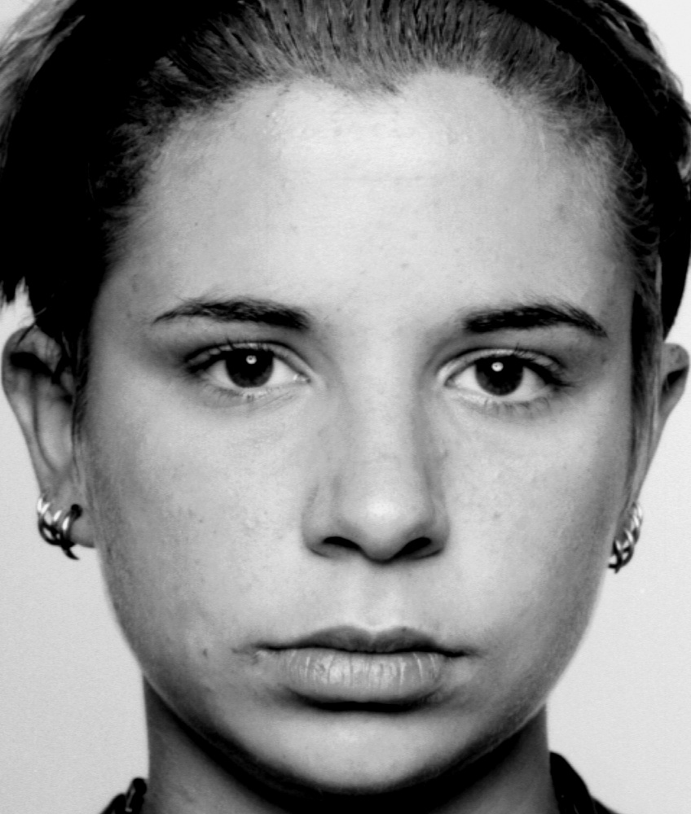

```
6 = neutral
```

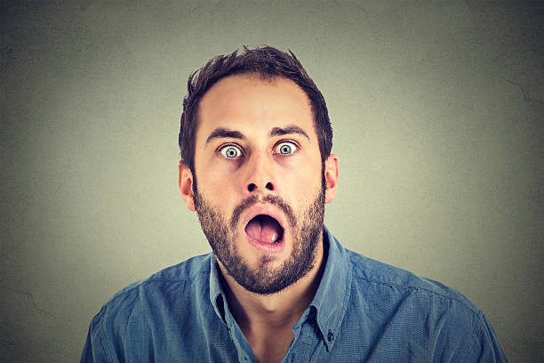

```
2 = fear
```

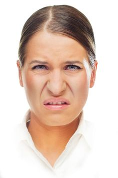

```
2 = fear
```

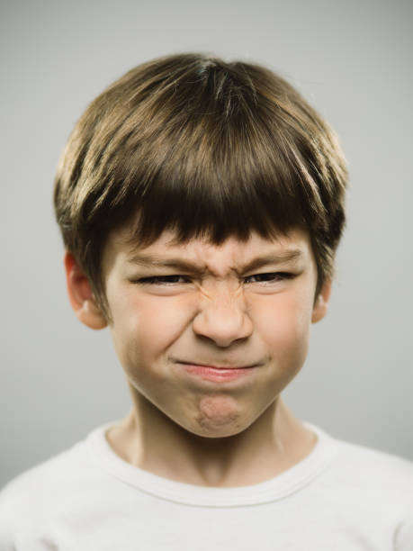

```
0 = angry
```

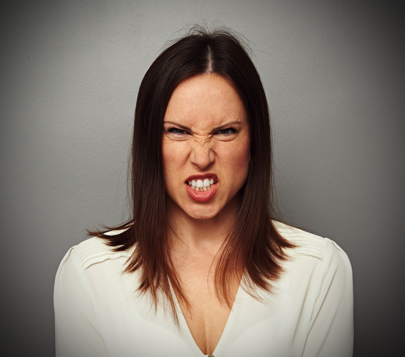

```
4 = sad
```

[figure not shown]

```
3 = happy
```

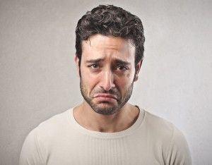

```
3 = happy
```

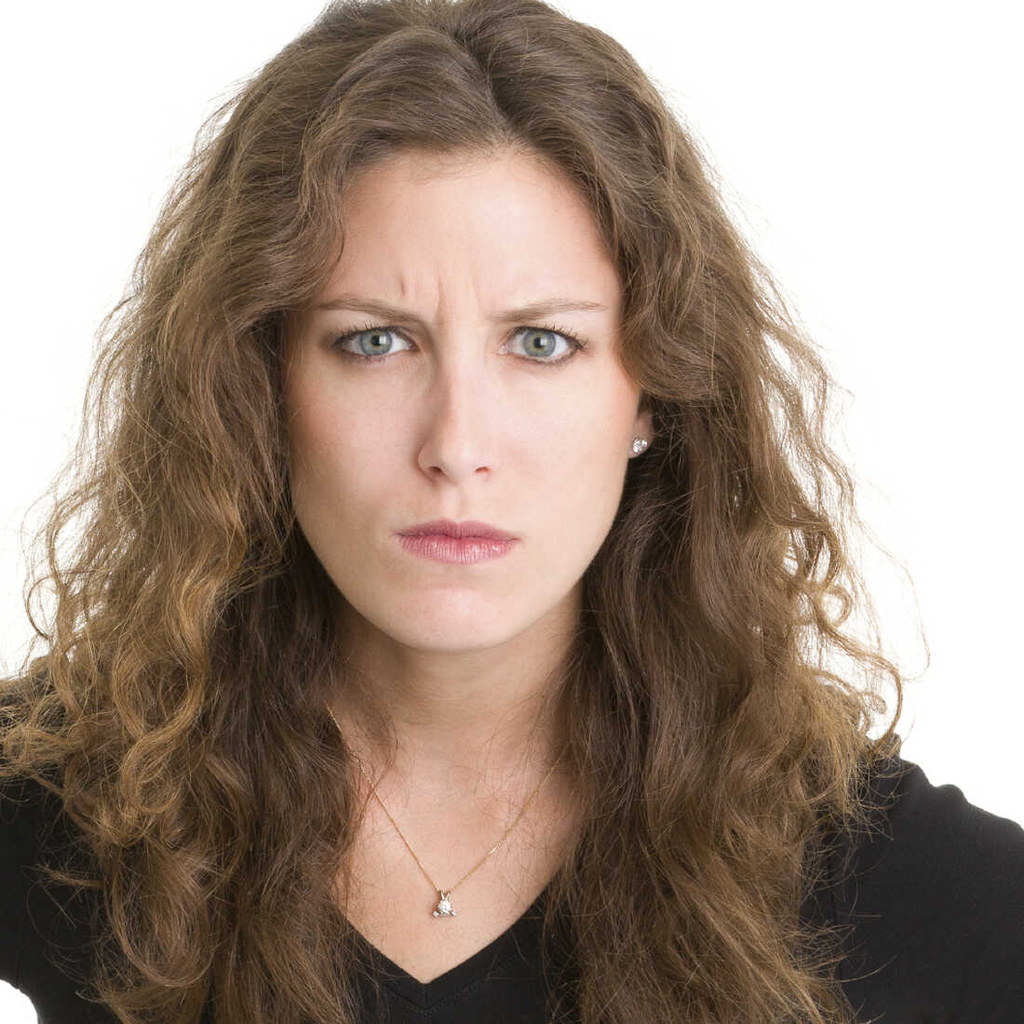

```
2 = fear
```

[figure not shown]

```
4 = sad
```

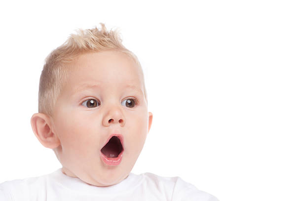

```
5 = surprise
```

```python
from IPython.display import Image, display
import matplotlib.pyplot as plt
import matplotlib.image as mpimg

TGREEN =  '\033[1;37;42m'
TRED =    '\033[1;37;41m'
TYELLOW = '\033[0;43m'

for i in range (0,10):
  img_directory = str(i) + '.jpg'
  img_data = tf.keras.utils.load_img(img_directory, target_size = (48, 48))   #load the image from the directory
  img_data = tf.keras.utils.img_to_array(img_data)                            #convert the image to a Numpy array
  img_data = tf.image.rgb_to_grayscale(img_data)

  #print(img_data.shape)
  #img_data = np.array(img_data, 'float32')
  #img_data.resize(48,48,1)
  #print(img_data.shape)
  img_data = np.expand_dims(img_data, axis = 0)                     #expands the array by inserting a new axis at the specified position.
  #print(img_data.shape)

  classify = model.predict(img_data)
  display(Image(img_directory,width= 150, height=150))
  #print("\n")
  max_index = np.argmax(classify[0])
  emotion_detection = ('angry', 'disgust', 'fear', 'happy', 'sad', 'surprise', 'neutral')
  emotion_prediction = emotion_detection[max_index]

  if(max_index == 3 or max_index == 5):
    print( str(max_index) + ' = ' +  emotion_prediction)
  elif(max_index == 4 or max_index == 2 or max_index == 0):
    print( str(max_index) + ' = ' +  emotion_prediction)
  else:
    print( str(max_index) + ' = ' +  emotion_prediction)
  print("\n")
  print("\n")
```

### Save the model

We will serialize the model to JSON and save the model's weights in a hd5 file, so we can use it to make predictions directly without retraining the model everytime.

```python
model_json = model.to_json()
with open("model.json", "w") as json_file:
  json_file.write(model_json)
  model.save_weights("model.h5")

print("Saved model to disk")
```

```
Saved model to disk
```